# 向量

# 目录

- 1 前提准备
- 2 向量基础
- 3 原子向量的数据类型
  - 3.1 逻辑向量
  - 3.2 数值向量
  - 3.3 字符向量
  - 3.4 缺失值
- 4 向量的使用
  - 4.1 强制转换向量的数据类型
  - 4.2 检测向量的数据类型
  - 4.3 自动补齐
  - 4.4 给向量中的元素命名
  - 4.5 索引
- 5 递归向量（列表）
  - 5.1 可视化列表
  - 5.2 索引
  - 5.3 调味品列表
- 6 属性
  - 6.1 面向对象编程
- 7 扩展向量
  - 7.1 因子
  - 7.2 日期和时间
  - 7.3 tibble

# 1 前提准备

```r
library(tidyverse)
```

# 2 向量基础

有两种类型的向量：

- 1 **原子向量 Atomic vectors**：分为6种类型，**logical** 、 **integer** 、 **double** 、 **character** 、 **complex** 和 **raw** ，其中 integer 和 double 合称为 **numeric** 。
- 2 **列表 Lists**：也被称为递归向量，因为列表中可以包含列表

两种类型向量最主要的差别在于：原子向量的元素都是**同质**的，而列表的元素可以是**异质**的。

每个向量都有2个属性：

- 1 **数据类型 type**

```r
typeof(letters)
```

```
[1] "character"
```

```r
typeof(1:10)
```

```
[1] "integer"
```

- 2 **长度 length**

```r
x <- list("a", "b", 1:10)
length(x)
```

```
[1] 3
```

向量能够以属性的形式包含附加的元数据，这些属性可以用于构建 **扩展向量 augmented vectors** 。主要有以下几种扩展向量：

- 因子：在整数向量基础上构建
- 日期和时间：在数值向量基础上构建
- data.frame 和 tibble ：在列表基础上构建

接下来将会按照原子向量、列表、扩展向量的顺序进行介绍。

# 3 原子向量的数据类型

数据分析中主要使用4种类型的向量：逻辑向量、整数向量、双精度向量、字符向量。

## 3.1 逻辑向量

逻辑向量是最简单的向量类型，因为它只有3种取值： `TRUE` 、 `FALSE` 、 `NA` 。逻辑向量可以通过比较操作和 `c()` 构造：

```r
1:10 %% 3 == 0
```

```
 [1] FALSE FALSE  TRUE FALSE FALSE  TRUE FALSE FALSE  TRUE FALSE
```

```r
c(TRUE, TRUE, FALSE, NA)
```

```
[1]  TRUE  TRUE FALSE    NA
```

## 3.2 数值向量

整数向量和双精度向量合称为数值向量。在 R 中，数值默认为双精度，如果想创建整数，需要在数字后面加上 `L` ：

```r
typeof(1)
```

```
[1] "double"
```

```r
typeof(1L)
```

```
[1] "integer"
```

```r
1.5L
```

```
integer literal 1.5L contains decimal; using numeric value
```

```
[1] 1.5
```

整数和双精度数有两个重要的差别：

- 1 双精度数是估计值。在固定的内存下，双精度数并不总是完全精确。例如：

```r
x <- sqrt(2) ^ 2
x
```

```
[1] 2
```

```r
x - 2
```

```
[1] 4.440892e-16
```

进行双精度数的比较时，不要使用 `==` ，可以使用 `dplyr::near()` ，该函数允许一定的误差。

- 2 整数只有一个特殊值 `NA` ，而双精度数有四个特殊值： `NA` 、 `NaN` 、 `Inf` 、 `-Inf` 。

```r
c(-1, 0, 1) / 0
```

```
[1] -Inf  NaN  Inf
```

对这四种特殊值进行比较操作，不能使用 `==` ，而要使用 `is.finite()` 、 `is.infinite()` 、 `is.nan()` ：

[output not shown]

## 3.3 字符向量

字符向量是最复杂的向量类型，因为每个元素都是一个字符串，而字符串会包含任意多个字符。

R 中会构建一个全局的字符串池子（ a global string pool ）。这意味着每个字符串在内存中只会被储存一次，每次使用字符串，只是对内存中的这个字符串的一个引用。复制字符串时，这一特性可以起到节省内存的作用：

```r
x <- "This is a reasonably long string."
pryr::object_size(x)
```

```
136 B
```

```r
y <- rep(x, 1000)
pryr::object_size(y)
```

```
8.13 kB
```

`y` 占用的内存并不是 `x` 的1000倍，因为 `y` 中的每一个元素都是只是对同一个字符串的指针。每个指针占用8 B ，对136 B 的字符串创建1000个指针，一共占用内存 8 * 1000 + 136 = 8.13 kB 。

## 3.4 缺失值

每一种类型的向量都有自己独有的缺失值：

```r
NA            # logical
```

```
[1] NA
```

```r
NA_integer_   # integer
```

```
[1] NA
```

```r
NA_real_      # double
```

```
[1] NA
```

```r
NA_character_ # character
```

```
[1] NA
```

通常不会用到这些特定类型的缺失值，因为 R 会自动将 `NA` 转化为需要的数据类型。

# 4 向量的使用

## 4.1 强制转换向量的数据类型

有两种方式可以转换向量的数据类型：

- 1 显式转换：使用函数 `as.logical()` 、 `as.integer()` 、 `as.double()` 、 `as.character()` 转换向量的数据类型。
- 2 隐式转换：当你在需要使用特定数据类型的向量时，会发生隐式转换。
- 对逻辑向量使用数值统计函数：

```r
x <- sample(20, 100, replace = TRUE)
y <- x > 10
sum(y)  # how many are greater than 10?
```

```
[1] 59
```

```r
mean(y) # what proportion are greater than 10?
```

```
[1] 0.59
```

- 将向量的长度转换为布尔值：

```r
if (length(x)) {
  # do something
}
```

```r
if (length(x) > 0) {
  # do something
}
```

- 将不同类型的元素放在同一个向量中，会强制转换为最复杂的数据类型，优先级如下：

```r
typeof(c(TRUE, 1L))
```

```
[1] "integer"
```

```r
typeof(c(1L, 1.5))
```

```
[1] "double"
```

```r
typeof(c(1.5, "a"))
```

```
[1] "character"
```

## 4.2 检测向量的数据类型

- `R` 中的 `typeof()` 、 `is.vector()` 、 `is.atomic()` 等函数
- `purrr` 中的 `is_*` 函数

|  | lgl | int | dbl | chr | list |
| --- | --- | --- | --- | --- | --- |
| `is_logical()` | x |  |  |  |  |
| `is_integer()` |  | x |  |  |  |
| `is_double()` |  |  | x |  |  |
| `is_numeric()` |  | x | x |  |  |
| `is_character()` |  |  |  | x |  |
| `is_atomic()` | x | x | x | x |  |
| `is_list()` |  |  |  |  | x |
| `is_vector())` | x | x | x | x | x |

每个函数都有一个标量版本，例如 `is_scalar_atomic()` ，可以检测对象是否为特定数据类型的标量。

## 4.3 自动补齐

在 R 中对长度不同的向量进行运算时，会自动重复长度较短的向量，使向量的长度保存一致。

```r
sample(10) + 100
```

```
 [1] 110 108 101 102 104 105 106 103 109 107
```

```r
runif(10) > 0.5
```

```
 [1]  TRUE  TRUE  TRUE  TRUE  TRUE FALSE  TRUE  TRUE FALSE FALSE
```

```r
1:10 + 1:2
```

```
 [1]  2  4  4  6  6  8  8 10 10 12
```

但是当长向量的长度并非短向量的整数倍时，会产生一个 warning：

```r
1:10 + 1:3
```

```
longer object length is not a multiple of shorter object length
```

```
 [1]  2  4  6  5  7  9  8 10 12 11
```

由于这种自动补齐的功能也存在产生错误的可能， `tidyverse` 中的函数在对不同长度的向量自动补齐时会报错 （除非对象是向量和标量）：

```r
tibble(x = 1:4, y = 1:2)
```

```
Error: Variables must be length 1 or 4.
Problem variables: 'y'
```

```r
tibble(x = 1, y = 1:2)
```

| x | y |
| --- | --- |
| 1 | 1 |
| 1 | 2 |

```
#> # A tibble: 2 × 2
#>       x     y
#>   <dbl> <int>
#> 1     1     1
#> 2     1     2
```

使用 `rep()` 函数来解决这一问题：

```r
tibble(x = 1:4, y = rep(1:2, 2))
```

| x | y |
| --- | --- |
| 1 | 1 |
| 2 | 2 |
| 3 | 1 |
| 4 | 2 |

```
#> # A tibble: 4 × 2
#>       x     y
#>   <int> <int>
#> 1     1     1
#> 2     2     2
#> 3     3     1
#> 4     4     2
```

```r
tibble(x = 1:4, y = rep(1:2, each = 2))
```

| x | y |
| --- | --- |
| 1 | 1 |
| 2 | 1 |
| 3 | 2 |
| 4 | 2 |

```
#> # A tibble: 4 × 2
#>       x     y
#>   <int> <int>
#> 1     1     1
#> 2     2     1
#> 3     3     2
#> 4     4     2
```

## 4.4 给向量中的元素命名

- 在创建向量时命名

```r
c(x = 1, y = 2, z = 4)
```

```
x y z
1 2 4
```

- 使用 `purrr::set_names()` 给向量命名

```r
set_names(1:3, c("a", "b", "c"))
```

```
a b c
1 2 3
```

## 4.5 索引

使用 `[` 从向量中索引，有4种使用方式：

- 1 整数索引，必须全部是正数、负数或零： 使用正数会选取对应位置的元素

```r
x <- c("one", "two", "three", "four", "five")
x[c(3, 2, 5)]
```

```
[1] "three" "two"   "five"
```

```r
x[c(1, 1, 5, 5, 5, 2)]
```

```
[1] "one"  "one"  "five" "five" "five" "two"
```

使用负数会丢弃对应位置的元素

```r
x[c(-1, -3, -5)]
```

```
[1] "two"  "four"
```

混合使用正数和负数会报错

```r
x[c(1, -1)]
```

```
Error in x[c(1, -1)] : only 0's may be mixed with negative subscripts
```

使用零会返回 `character(0)`

```r
x[0]
```

```
character(0)
```

- 2 布尔索引

```r
x <- c(10, 3, NA, 5, 8, 1, NA)
```

```r
# All non-missing values of x
x[!is.na(x)]
```

```
[1] 10  3  5  8  1
```

```r
# All even (or missing!) values of x
x[x %% 2 == 0]
```

```
[1] 10 NA  8 NA
```

- 3 元素名索引

```r
x <- c(abc = 1, def = 2, xyz = 5)
x[c("xyz", "def")]
```

```
xyz def
  5   2
```

- 4 `x[]` `x[]` 会返回整个 `x`

```r
x[]
```

```
abc def xyz
  1   2   5
```

这一特性用于对矩阵等高维数据结构进行索引。例如，如果 `x` 是2维的， `x[1, ]` 将会返回第一行并保留全部列， `x[, -1]` 将会丢弃第一列并保留全部行。

- 使用 `[[` 进行索引，只能够提取单个元素，并且会丢掉元素名。

# 5 递归向量（列表）

列表可以包含列表，适合存储层次结构和树形结构的数据。

- 使用 `list()` 创建列表：

```r
x <- list(1, 2, 3)
x
```

```
[[1]]
[1] 1

[[2]]
[1] 2

[[3]]
[1] 3
```

- 使用 `str()` 查看列表的结构：

```r
str(x)
```

```
List of 3
 $ : num 1
 $ : num 2
 $ : num 3
```

```r
x_named <- list(a = 1, b = 2, c = 3)
str(x_named)
```

```
List of 3
 $ a: num 1
 $ b: num 2
 $ c: num 3
```

- 列表可以包含不同类型的元素：

```r
y <- list("a", 1L, 1.5, TRUE)
str(y)
```

```
List of 4
 $ : chr "a"
 $ : int 1
 $ : num 1.5
 $ : logi TRUE
```

- 列表中可以包含列表：

```r
z <- list(list(1, 2), list(3, 4))
str(z)
```

```
List of 2
 $ :List of 2
  ..$ : num 1
  ..$ : num 2
 $ :List of 2
  ..$ : num 3
  ..$ : num 4
```

## 5.1 可视化列表

```r
x1 <- list(c(1, 2), c(3, 4))
x2 <- list(list(1, 2), list(3, 4))
x3 <- list(1, list(2, list(3)))
```

上面3个列表的结构如下：

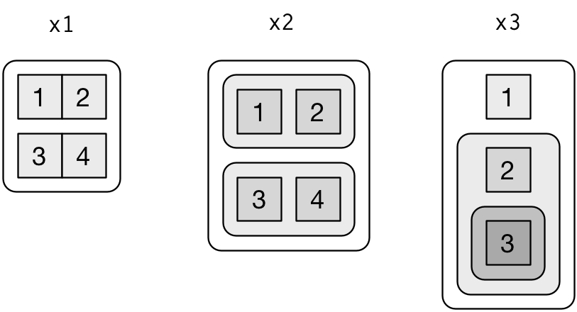

## 5.2 索引

有3种方式可以索引列表 `a` ：

```r
a <- list(a = 1:3, b = "a string", c = pi, d = list(-1, -5))
a
```

```
$a
[1] 1 2 3

$b
[1] "a string"

$c
[1] 3.141593

$d
$d[[1]]
[1] -1

$d[[2]]
[1] -5
```

- `[` 提取子列表，并返回一个列表：

```r
a[1:2]
```

```
$a
[1] 1 2 3

$b
[1] "a string"
```

```r
a[4]
```

```
$d
$d[[1]]
[1] -1

$d[[2]]
[1] -5
```

- `[[` 提取列表中的单个元素，返回的数据格式取决于该元素的数据格式，并且会对列表降维（移除最外层的列表层次）：

```r
a[[1]]
```

```
[1] 1 2 3
```

```r
a[[4]]
```

```
[[1]]
[1] -1

[[2]]
[1] -5
```

- `$` 按元素名提取列表中的单个元素，元素名不需要引号：

```r
a$a
```

```
[1] 1 2 3
```

```r
a[["a"]]
```

```
[1] 1 2 3
```

注意 `[` 和 `[[` 的区别：

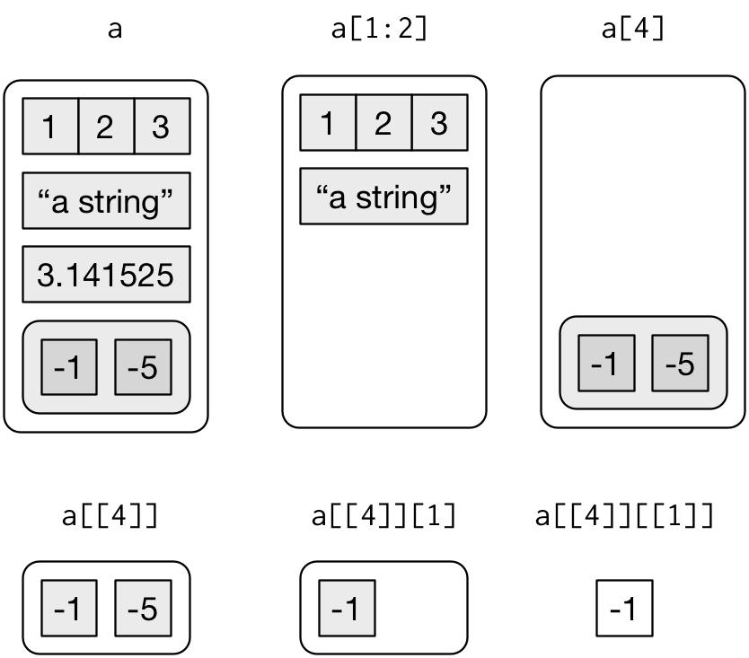

## 5.3 调味品列表

`[` 和 `[[` 的区别十分重要，下面用一个胡椒粉调料瓶来形象地展示这种区别：

[figure not shown]

如果这个调料瓶是列表 `x` ，那么 `x[1]` 是包含了一小包胡椒粉的调料瓶：

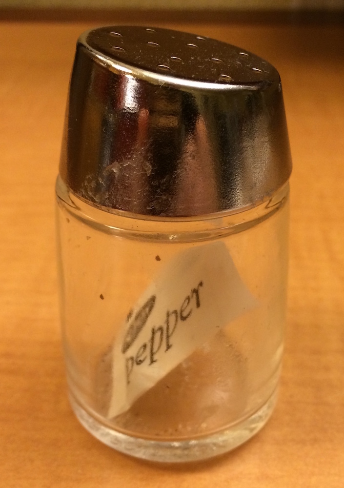

`x[2]` 是包含了第二包胡椒粉的调料瓶， `x[1:2]` 是包含了两包胡椒粉的调料瓶。

而 `x[[1]]` 是一小包胡椒粉：

[figure not shown]

`x[[1]][[1]]` 则是胡椒粉：

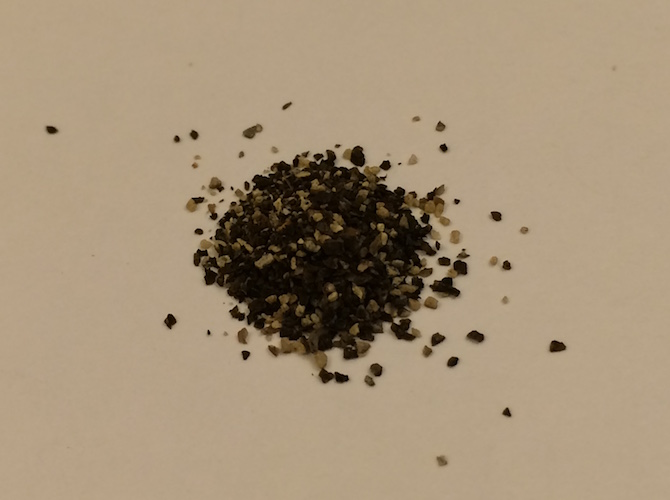

# 6 属性

任何对象都可以有以列表形式存在的**属性（attributes）**。可以使用 `attr()` 获取和创建单个属性，或使用 `attributes()` 获取全部属性：

```r
x <- 1:10
attr(x, "greeting")
```

```r
attr(x, "greeting") <- "Hi!"
attr(x, "farewell") <- "Bye!"
attributes(x)
```

```
$greeting
[1] "Hi!"

$farewell
[1] "Bye!"
```

在 R 中有3个非常重要的属性：

- 1 **名字（name）**：为向量的元素命名
- 2 **维度（dimension）**：使向量可以像矩阵、数组一样操作
- 3 **类（class）**：实现 S3 面向对象编程

## 6.1 面向对象编程

一个典型的通用函数（generic function）如下：

```r
as.Date
```

```
function (x, ...)
UseMethod("as.Date")
<bytecode: 0x00000000158ae6d8>
<environment: namespace:base>
```

UseMethod 意味着该函数是一个通用函数，可以根据传入参数的类来调用特定的方法（method）。使用 `methods()` 函数查看该函数的所有方法：

```r
methods("as.Date")
```

```
[1] as.Date.character as.Date.date      as.Date.dates     as.Date.default   as.Date.factor    as.Date.numeric
[7] as.Date.POSIXct   as.Date.POSIXlt
see '?methods' for accessing help and source code
```

如果 `x` 是一个字符向量， `as.Date()` 会调用 `as.Date.character()` ；如果 `x` 是一个因子， `as.Date()` 会调用 `as.Date.factor()` 。

通过 `getS3method()` 函数可以查看某个方法的具体实现：

```r
getS3method("as.Date", "default")
```

```
function (x, ...)
{
    if (inherits(x, "Date"))
        return(x)
    if (is.logical(x) && all(is.na(x)))
        return(structure(as.numeric(x), class = "Date"))
    stop(gettextf("do not know how to convert '%s' to class %s",
        deparse(substitute(x)), dQuote("Date")), domain = NA)
}
<bytecode: 0x0000000014ee5830>
<environment: namespace:base>
```

```r
getS3method("as.Date", "numeric")
```

```
function (x, origin, ...)
{
    if (missing(origin))
        stop("'origin' must be supplied")
    as.Date(origin, ...) + x
}
<bytecode: 0x0000000014ee3640>
<environment: namespace:base>
```

`print()` 、 `[` 、 `[[` 、 `$` 都是很重要的 S3 通用函数。

# 7 扩展向量

原子向量和列表是其他类型向量的基础。这些向量被称为扩展向量，因为它们是拥有额外属性的向量。

## 7.1 因子

因子建立在整数向量的基础上，拥有 `levels` 属性：

```r
x <- factor(c("ab", "cd", "ab"), levels = c("ab", "cd", "ef"))
typeof(x)
```

```
[1] "integer"
```

```r
attributes(x)
```

```
$levels
[1] "ab" "cd" "ef"

$class
[1] "factor"
```

## 7.2 日期和时间

- 日期是数值向量，其实质是距1970年1月1日的天数：

```r
x <- as.Date("1971-01-01")
unclass(x)
```

```
[1] 365
```

```r
typeof(x)
```

```
[1] "double"
```

```r
attributes(x)
```

```
$class
[1] "Date"
```

- 日期-时间是数值向量，拥有 `POSIXct` (“Portable Operating System Interface” calendar time) 类，其实质是距1970年1月1日的秒数：

```r
x <- lubridate::ymd_hm("1970-01-01 01:00")
unclass(x)
```

```
[1] 3600
attr(,"tzone")
[1] "UTC"
```

```r
typeof(x)
```

```
[1] "double"
```

```r
attributes(x)
```

```
$tzone
[1] "UTC"

$class
[1] "POSIXct" "POSIXt"
```

`tzone` 属性是可选的，只影响时间的显示方式，而不影响时间的内容：

```r
attr(x, "tzone") <- "US/Pacific"
x
```

```
[1] "1969-12-31 17:00:00 PST"
```

```r
attr(x, "tzone") <- "US/Eastern"
x
```

```
[1] "1969-12-31 20:00:00 EST"
```

- 还有一种日期-时间类型 `POSIXlt` ，建立在列表的基础上：

```r
y <- as.POSIXlt(x)
typeof(y)
```

```
[1] "list"
```

```r
attributes(y)
```

```
$names
 [1] "sec"    "min"    "hour"   "mday"   "mon"    "year"   "wday"   "yday"   "isdst"  "zone"   "gmtoff"

$class
[1] "POSIXlt" "POSIXt"

$tzone
[1] "US/Eastern" "EST"        "EDT"
```

可以使用 `lubridate::as_date_time()` 将 `POSIXlt` 转换为更容易使用的 `POSIXct` 。

## 7.3 tibble

tibble 是加强型的列表，拥有 `tbl_df` 、 `tbl` 、 `data.frame` 类，以及 `names` 和 `row.names` 属性：

```r
tb <- tibble::tibble(x = 1:5, y = 5:1)
typeof(tb)
```

```
[1] "list"
```

```r
attributes(tb)
```

```
$names
[1] "x" "y"

$class
[1] "tbl_df"     "tbl"        "data.frame"

$row.names
[1] 1 2 3 4 5
```

tibble 和 列表的差别在于： tibble 要求所有的元素都必须是长度一致的向量。

传统的 data.frame 结构与 tibble 相似：

```r
df <- data.frame(x = 1:5, y = 5:1)
typeof(df)
```

```
[1] "list"
```

```r
attributes(df)
```

```
$names
[1] "x" "y"

$row.names
[1] 1 2 3 4 5

$class
[1] "data.frame"
```

tibble 的类包含了 data.frame ，意味着 tibble 继承了 data.frame 的所有特性。